# Memory and Memory Profiling in R

Statistics 506, Fall 2019

## Resources

The material in this lesson is largely based on:

- [Chapter 18](http://adv-r.had.co.nz/memory.html) of the first edition of *Advanced R*.
- Chapter 14 of *The Art of R Programming*.

## General Information on Memory

You likely already know that binary data is composed of bits (0 or 1). You may also know that computer systems generally use [bytes](https://en.wikipedia.org/wiki/Byte) containing multiple bits as the basic addressable unit.

In modern computer architectures a byte usually consists of 8 bits. When describing a [data storage](https://en.wikipedia.org/wiki/File_size) quantity in terms of bytes we traditionally use prefixes based on powers of 2, so that 1KB $= 2^{10} (1024)$ bytes, a MB = $2^{20}$ (1,048,576) bytes etc. But SI prefixes using base 10 are now more common common, 1kB = 1e3 bytes, 1 MB = 1e6 bytes.

You may also want to review the section ‘Storage’ from Professor Shedden’s [notes](http://dept.stat.lsa.umich.edu/~kshedden/Courses/Stat506/computer_architecture/).

An understanding of [virtual memory](https://en.wikipedia.org/wiki/Virtual_memory), segmentation, and caching may be of use at some point in the future but is not required for this course.

### Understanding memory usage in R

A useful tool for exploring memory management in R is Hadley Wickham’s [`pryr`](https://github.com/hadley/pryr) package. It contains a function `pryr::object_size` similar to `object.size` but with these differences:

- It accounts for memory shared by elements in an object
- It attempts to account for memory from environments associated with an object.

Here are some examples.

```r
library(pryr); library(ggplot2)

nyc14 = data.table::fread('https://github.com/arunsrinivasan/flights/wiki/NYCflights14/flights14.csv')

# Simple size of objects
object.size(1:10)
```

```
## 96 bytes
```

```r
pryr::object_size(1:10)
```

```
## 96 B
```

```r
object.size(nyc14)
```

```
## 21501712 bytes
```

```r
print(object.size(nyc14), units='MB', standard = 'SI')
```

```
## 21.5 MB
```

```r
object_size(nyc14)
```

```
## 21.5 MB
```

```r
compare_size(nyc14)
```

```
##     base     pryr
## 21501712 21500520
```

```r
## How to understand the difference?
# Example from object_size documentation.
x = 1:1e5
z = list(x, x, x)
compare_size(z)
```

```
##    base    pryr
## 1200224  400128
```

```r
object_size(x)
```

```
## 400 kB
```

```r
object_size(z)
```

```
## 400 kB
```

```r
object_size(x, z)
```

```
## 400 kB
```

```r
print(object.size(x), units = 'kB', standard = 'SI')
```

```
## 400 kB
```

```r
print(object.size(z), units = 'kB', standard = 'SI')
```

```
## 1200.2 kB
```

To understand this last example, we need to recall R’s “copy on modify semantics” discussed during the lessons on `data.table`. Here we will use the function `tracemem()` to get the memory address of an object. When this changes we can be sure that an object has been copied. Similar functionality is available via `pryr::address()` or `data.table::address()`.

```r
## Recall R has "copy-on-modify semantics"
invisible(tracingState(on=FALSE))
tracemem(x)
```

```
## [1] "<0x7fc0882ffcf8>"
```

```r
tracemem(z)
```

```
## [1] "<0x7fc0856b0eb8>"
```

```r
## pryr::address doesn't work well with knitr, but would be the
## same interactively
pryr::address(z)
```

```
## [1] "0x7fc0856b0eb8"
```

```r
data.table::address(z)
```

```
## [1] "0x7fc0856b0eb8"
```

```r
inspect(z)
```

```
## <VECSXP 0x7fc0856b0eb8>
##   <INTSXP 0x7fc0882ffcf8>
##   [INTSXP 0x7fc0882ffcf8]
##   [INTSXP 0x7fc0882ffcf8]
```

```r
# Modify z, tracemem causes message to print
z[[2]] = -x

sapply(z, tracemem)
```

```
## [1] "<0x7fc0882ffcf8>" "<0x110ad3000>"    "<0x7fc0882ffcf8>"
```

```r
# Having changed z[[2]], the object is larger.
object_size(z)
```

```
## 800 kB
```

```r
object_size(x,z)
```

```
## 800 kB
```

Here is an example of how environments impact `object_size`.

```r
f <- function(){
  x <- 1:1e5
  a ~ b
}
compare_size(f())
```

```
##   base   pryr
##    728 400888
```

```r
g <- function(){
  a ~ b
}
compare_size(g())
```

```
## base pryr
##  728  728
```

```r
h <- function(){
  x <- 1:1e5
  x ~ y
}
compare_size(h())
```

```
##   base   pryr
##    728 400832
```

```r
object_size(a ~ b)
```

```
## 672 B
```

```r
object_size(1:1e5)
```

```
## 400 kB
```

Two other useful functions from `pryr` are `mem_used()` which adds up the total size of all objects in memory and `mem_change()` which tracks changes to this quantity. When working with `mem_change()` ignore anything ~2KB or smaller as this mostly is impacted by changes to .Rhistory.

```r
ls()
```

```
## [1] "f"     "g"     "h"     "nyc14" "x"     "z"
```

```r
mem_used()
```

```
## 73.3 MB
```

```r
mem_change({new_vec = 1:1e6 * 1L})
```

```
## 4 MB
```

```r
# Negatives represent memory freed
mem_change(rm(new_vec))
```

```
## -4 MB
```

```r
mem_change(rm(nyc14))
```

```
## -21.5 MB
```

### Vector size

This example is taken from section 18.1 of the first edition of *Advanced R*.

Here we exam the size, in bytes, of R vectors of class integer with lengths 0 through 100.

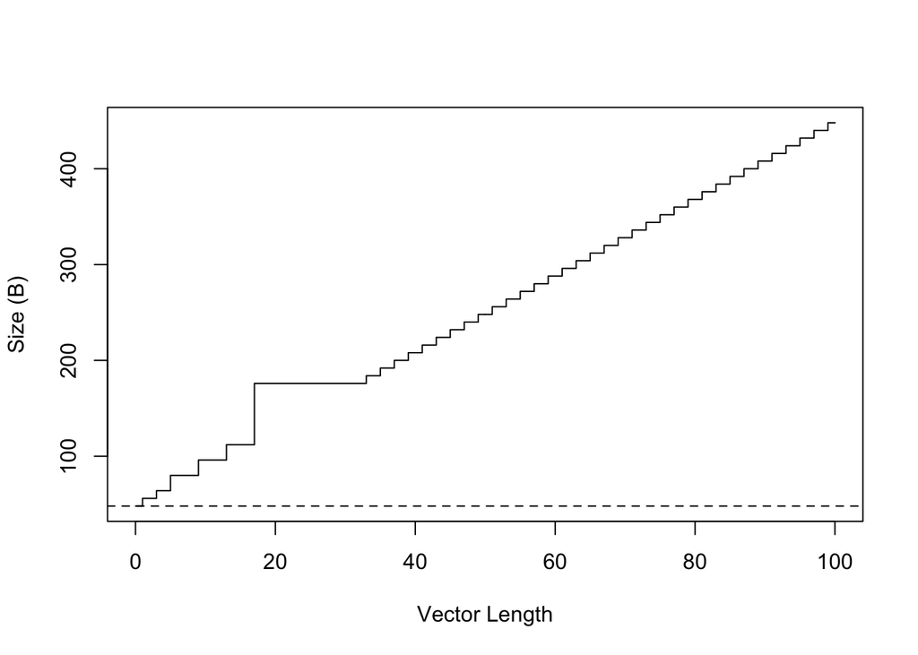

```r
sizes = sapply(0:100, function(n) object_size(seq_len(n)))
plot(0:100, sizes, xlab='Vector Length', ylab='Size (B)', type='s')
abline(h=48, lty='dashed')
```

```r
sizes[1:20]
```

```
##  [1]  48  56  56  64  64  80  80  80  80  96  96  96  96 112 112 112 112
## [18] 176 176 176
```

It turns out that empty vectors of any type occupy 48 bytes of memory,

```r
sapply(c('numeric', 'logical', 'integer', 'raw', 'list'),
       function(x) object_size(vector(mode=x, length=0))
       )
```

```
## numeric logical integer     raw    list
##      48      48      48      48      48
```

These bytes are used to store the following components:

1. Metadata including the type and some other information
2. Pointers to the next and previous object in memory.
3. A pointer to the attributes.
4. Vector length
5. “True length” used primarily for environments.

How do we interpret the remaining steps in the graph? First, consider the regular steps for the later vectors:

```r
diff(sizes[41:45])
```

```
## [1] 8 0 8 0
```

For vectors beyond 128 bytes in size (excluding overhead) R requests memory from the OS in 8 byte chunks using the C function `malloc()`. Since an integer occupies 4 bytes, the memory increases every other integer.

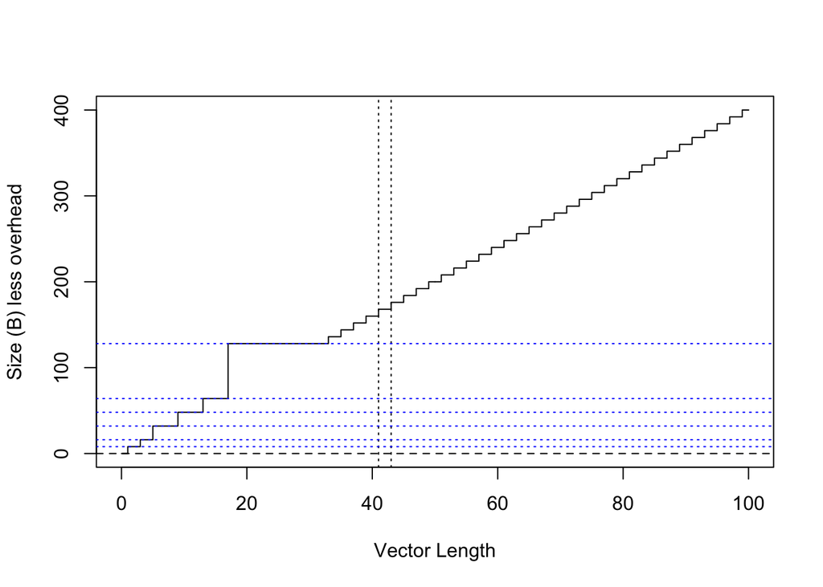

```r
## Adjusted sizes
plot(0:100, sizes - 48, xlab='Vector Length', ylab='Size (B) less overhead', type='s')
abline(h=0,lty='dashed')
abline(v=c(41, 43), lty='dotted')
abline(h={8*c(1, 2, 4, 6, 8, 16)}, col='blue', lty='dotted')
```

#### Exercises

**Question 1:** What vector lengths are shown by the vertical lines in the plot below? Where do the horizontal lines intersect the y-axis?

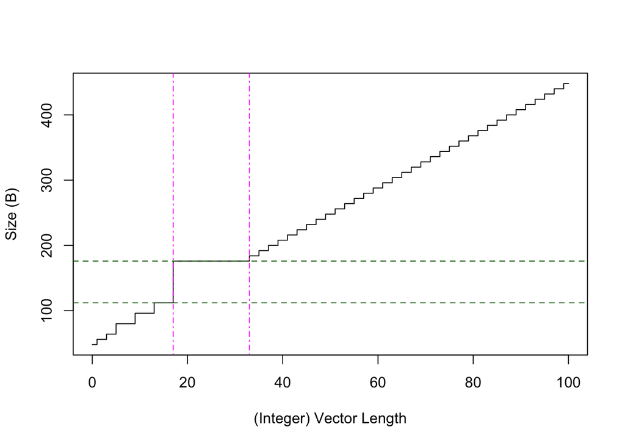

**Question 2:** Recall that an integer type is stored using 4 bytes while the double type uses 8 bytes. What are the values of `a` and `b` after running the R code below?

```r
a = object_size(1:15)
b = object_size(as.numeric(1:15))

unique( sizes[sizes < {128 + 48}] - 48 )
```

```
## [1]  0  8 16 32 48 64
```

**Question 3:** What are the approximate values of mem_a - mem_c below?

```r
x = 1:1e6
z = list(x, x, x)
object_size(x, z)
```

```
## 4 MB
```

```r
mem_a = object_size(z) - object_size(x)                   # Exact in bytes
mem_b = mem_change(z[[1]] <- rep(2L, 1e6))                # Approximate in Mb
mem_c = mem_change(z[[2]][sample(1:1e6, 1)] <-  runif(1)) # Approximate in Mb
```

### Strings and factors

We noted above that integers are stored using 4 bytes (32 bits) and doubles 8 bytes (64 bits). What about characters? According to the R [documenation](https://cran.r-project.org/doc/manuals/r-devel/R-ints.html#The-CHARSXP-cache) on CRAN, R uses a global pool of strings and pointers to them in actual strings.

```r
# pointers to strings take 8 bytes each
x = 'abc'
x1e5 = rep(x, 1e5)
object_size(x)
```

```
## 112 B
```

```r
object_size(x1e5)
```

```
## 800 kB
```

```r
compare_size(x1e5)
```

```
##   base   pryr
## 800104 800104
```

```r
object_size(x, x1e5)
```

```
## 800 kB
```

The global pool stores both the encoding of each string and the actual bytes.

In contrast, R objects of class `factor` are stored as integers encoding the levels which are in turn strings. Since integers occupy only 4 bytes, if there are only a few levels the factor can have a smaller memory footprint.

```r
x = sample(1:3, 1e5, replace=TRUE)
object_size(x) - 48
```

```
## 400 kB
```

```r
x_char = LETTERS[x]
object_size(x_char) - 48
```

```
## 800 kB
```

```r
x_factor = as.factor(x_char)
object_size(x_factor) - 48
```

```
## 401 kB
```

In contrast, if there are many levels the factor may have a larger footprint. Read more from `data.table` author Matt Dowle [here](https://stackoverflow.com/questions/34862856/are-factors-stored-more-efficiently-in-data-table-than-characters).

## Profiling with `Rprof` and `profviz`

### Example: Screening Correlation Coefficients

Recall our comparisons of various R implementations for screening correlation coefficients for a large number of possible predictors in the rows of a matrix `xmat` with a single outcome `y`. Here we will add a Fisher transform as well and return just the indices where the sample coefficients is nominally significant.

```r
# Example data
n = 3e2
m = 1e5
yvec = rnorm(n)
xmat = outer(array(1, m), yvec)
rmat = matrix(runif(m, -.8, .8), m, n)
xmat = rmat*xmat + sqrt(1 - rmat^2)*rnorm(n * m)

object_size(xmat)
```

```
## 240 MB
```

```r
object_size(yvec)
```

```
## 2.45 kB
```

```r
# When memory is an issue, be sure to clean up when possible.
mem_change(rm(rmat))
```

```
## -240 MB
```

```r
# Functions to compare
cor_screen_1 = function(yvec, xmat){
  r1 = NULL
  for (i in 1:m) {
    r1[i] = cor(xmat[i, ], yvec)
  }
  z = {.5*{log(1+r1) - log(1-r1)}}*sqrt(length(yvec)-3)

  which(abs(z)>qnorm(.975))
}

cor_screen_2 = function(yvec, xmat){
  r2 = apply(xmat, 1, function(v) cor(v, yvec))
  z = {.5*{log(1+r2) - log(1-r2)}}*sqrt(length(yvec)-3)

  which(abs(z)>qnorm(.975))
}


cor_screen_3 = function(yvec, xmat){
  rmn = rowMeans(xmat)
  xmat_c = xmat - outer(rmn, array(1, n))
  rsd = apply(xmat, 1, sd)
  xmat_s = xmat_c / outer(rsd, array(1, n))
  yvec_s = {yvec - mean(yvec)} / sd(yvec)
  r3 = xmat_s %*% yvec_s / {n - 1}

  z = as.vector({.5*{log(1+r3) - log(1-r3)}} * sqrt(length(yvec)-3))

  which(abs(z)>qnorm(.975))
}

cor_screen_4 = function(yvec, xmat){
  rmn = rowMeans(xmat)
  xmat_c = xmat - rmn
  rvar = rowSums(xmat_c^2) / {dim(xmat)[2] - 1}
  rsd = sqrt(rvar)
  xmat_s = xmat_c / rsd
  yvec_s = {yvec - mean(yvec)} / sd(yvec)
  r4 = xmat_s %*% yvec_s / {n - 1}

  z = as.vector({.5*{log(1+r4) - log(1-r4)}} * sqrt(length(yvec)-3))

  which(abs(z)>qnorm(.975))
}

# Check that all are equal
s = list(cor_screen_1(yvec, xmat), cor_screen_2(yvec, xmat),
         cor_screen_3(yvec, xmat), cor_screen_4(yvec, xmat)
         )
sapply(2:4, function(i) setdiff(s[[1]],s[[i]]))
```

```
## [[1]]
## integer(0)
##
## [[2]]
## integer(0)
##
## [[3]]
## integer(0)
```

Here is an example of profiling `cor_screen_1` for speed with `Rprof()`.

```r
Rprof(memory.profiling = TRUE, interval=.002)
 invisible(cor_screen_1(yvec, xmat))
Rprof(NULL)
summaryRprof(memory = 'both')
```

```
## $by.self
##                 self.time self.pct total.time total.pct mem.total
## "cor"               0.390    24.59      1.486     93.69    1484.4
## "is.data.frame"     0.298    18.79      0.298     18.79     296.5
## "stopifnot"         0.188    11.85      0.268     16.90     255.6
## "match.arg"         0.186    11.73      0.460     29.00     456.0
## "eval"              0.140     8.83      1.584     99.87    1575.9
## "cor_screen_1"      0.096     6.05      1.584     99.87    1575.9
## "pmatch"            0.054     3.40      0.056      3.53      66.6
## "formals"           0.042     2.65      0.100      6.31     102.3
## "sys.function"      0.038     2.40      0.058      3.66      65.2
## "...elt"            0.038     2.40      0.044      2.77      43.2
## "all"               0.024     1.51      0.024      1.51      20.2
## "sys.parent"        0.020     1.26      0.020      1.26      19.2
## "c"                 0.014     0.88      0.014      0.88      22.2
## "sys.frame"         0.014     0.88      0.014      0.88      13.0
## "as.character"      0.008     0.50      0.008      0.50       8.9
## "is.na"             0.008     0.50      0.008      0.50       8.3
## "is.atomic"         0.006     0.38      0.006      0.38       5.5
## "...length"         0.004     0.25      0.004      0.25       5.7
## "anyNA"             0.004     0.25      0.004      0.25      10.6
## "invisible"         0.004     0.25      0.004      0.25       1.5
## "is.matrix"         0.004     0.25      0.004      0.25       3.2
## "is.numeric"        0.004     0.25      0.004      0.25       6.9
## "which"             0.002     0.13      0.002      0.13       1.1
##
## $by.total
##                       total.time total.pct mem.total self.time self.pct
## "block_exec"               1.586    100.00    1576.8     0.000     0.00
## "call_block"               1.586    100.00    1576.8     0.000     0.00
## "evaluate_call"            1.586    100.00    1576.8     0.000     0.00
## "evaluate::evaluate"       1.586    100.00    1576.8     0.000     0.00
## "evaluate"                 1.586    100.00    1576.8     0.000     0.00
## "in_dir"                   1.586    100.00    1576.8     0.000     0.00
## "knitr::knit"              1.586    100.00    1576.8     0.000     0.00
## "process_file"             1.586    100.00    1576.8     0.000     0.00
## "process_group.block"      1.586    100.00    1576.8     0.000     0.00
## "process_group"            1.586    100.00    1576.8     0.000     0.00
## "rmarkdown::render"        1.586    100.00    1576.8     0.000     0.00
## "withCallingHandlers"      1.586    100.00    1576.8     0.000     0.00
```

[output cut: 19 more lines]

```
## "is.atomic"                0.006      0.38       5.5     0.006     0.38
## "...length"                0.004      0.25       5.7     0.004     0.25
## "anyNA"                    0.004      0.25      10.6     0.004     0.25
## "invisible"                0.004      0.25       1.5     0.004     0.25
## "is.matrix"                0.004      0.25       3.2     0.004     0.25
## "is.numeric"               0.004      0.25       6.9     0.004     0.25
## "which"                    0.002      0.13       1.1     0.002     0.13
## "sink"                     0.002      0.13       0.9     0.000     0.00
## "w$close"                  0.002      0.13       0.9     0.000     0.00
##
## $sample.interval
## [1] 0.002
##
## $sampling.time
## [1] 1.586
```

Here are two other options for the memory parameter.

```r
#summaryRprof(memory = 'tseries')
summaryRprof(memory = 'stats')
```

```
## index: "rmarkdown::render":"knitr::knit"
##      vsize.small  max.vsize.small      vsize.large  max.vsize.large
##            67539          4328616          1691032        975262272
##            nodes        max.nodes     duplications tot.duplications
##          1615126         42318304              505           400192
##          samples
##              793
```

### Using `profvis` to visualize profiling information

The [`profvis`](https://rstudio.github.io/profvis/) package is built on `Rprof()` but aims to provide more useful summary information.

#### 1

```r
#install.packages('profvis')
library(profvis)
profvis(cor_screen_1(yvec, xmat), interval = .005)
```

[interactive chart not shown]

#### 2

```r
profvis(cor_screen_2(yvec, xmat), interval = .005)
```

[interactive chart not shown]

#### 3

```r
profvis(cor_screen_3(yvec, xmat), interval = .005)
```

[interactive chart not shown]

#### 4

```r
profvis(cor_screen_4(yvec, xmat), interval = .005)
```

[interactive chart not shown]